# Lab 4

Author

Norma Marshall

## Lab 4

We will again work with the meteorological data presented in lecture.

The objective of the lab is to examine the association between weekly average dew point and wind speed in four regions of the US and by elevation.

## 1. Read in the Data

```r
if (!file.exists("met_all.gz"))
  download.file(
    url = "https://raw.githubusercontent.com/USCbiostats/data-science-data/master/02_met/met_all.gz",
    destfile = "met_all.gz",
    method   = "libcurl",
    timeout  = 60
    )
met <- data.table::fread("met_all.gz")



# Load required packages
library(data.table)
library(dplyr)
library(lubridate)
library(magrittr)
library(ggplot2)

 library(quarto)   # For rendering Quarto documents
library(knitr)    # For dynamic report generation
library(rmarkdown)
```

## Prepare the data

- Remove temperatures less than -17C *Make sure there are no missing data in the key variables coded as 9999, 999, etc
- Generate a date variable using the functions as.Date() (hint: You will need the following to create a date paste(year, month, day, sep = “-”)).
- Using the data.table::week function, keep the observations of the first week of the month.
- Compute the mean by station of the variables temp, rh, wind.sp, vis.dist, dew.point, lat, lon, and elev.
- Create a region variable for NW, SW, NE, SE based on lon = -98.00 and lat = 39.71 degrees
- Create a categorical variable for elevation as in the lecture slides

```r
head(met)
```

```
   USAFID  WBAN  year month   day  hour   min   lat      lon  elev wind.dir
    <int> <int> <int> <int> <int> <int> <int> <num>    <num> <int>    <int>
1: 690150 93121  2019     8     1     0    56  34.3 -116.166   696      220
2: 690150 93121  2019     8     1     1    56  34.3 -116.166   696      230
3: 690150 93121  2019     8     1     2    56  34.3 -116.166   696      230
4: 690150 93121  2019     8     1     3    56  34.3 -116.166   696      210
5: 690150 93121  2019     8     1     4    56  34.3 -116.166   696      120
6: 690150 93121  2019     8     1     5    56  34.3 -116.166   696       NA
   wind.dir.qc wind.type.code wind.sp wind.sp.qc ceiling.ht ceiling.ht.qc
        <char>         <char>   <num>     <char>      <int>         <int>
1:           5              N     5.7          5      22000             5
2:           5              N     8.2          5      22000             5
3:           5              N     6.7          5      22000             5
4:           5              N     5.1          5      22000             5
5:           5              N     2.1          5      22000             5
```

[output cut: 17 more lines]

```r
str(met)
```

```
Classes 'data.table' and 'data.frame':  2377343 obs. of  30 variables:
 $ USAFID           : int  690150 690150 690150 690150 690150 690150 690150 690150 690150 690150 ...
 $ WBAN             : int  93121 93121 93121 93121 93121 93121 93121 93121 93121 93121 ...
 $ year             : int  2019 2019 2019 2019 2019 2019 2019 2019 2019 2019 ...
 $ month            : int  8 8 8 8 8 8 8 8 8 8 ...
 $ day              : int  1 1 1 1 1 1 1 1 1 1 ...
 $ hour             : int  0 1 2 3 4 5 6 7 8 9 ...
 $ min              : int  56 56 56 56 56 56 56 56 56 56 ...
 $ lat              : num  34.3 34.3 34.3 34.3 34.3 34.3 34.3 34.3 34.3 34.3 ...
 $ lon              : num  -116 -116 -116 -116 -116 ...
 $ elev             : int  696 696 696 696 696 696 696 696 696 696 ...
 $ wind.dir         : int  220 230 230 210 120 NA 320 10 320 350 ...
 $ wind.dir.qc      : chr  "5" "5" "5" "5" ...
 $ wind.type.code   : chr  "N" "N" "N" "N" ...
 $ wind.sp          : num  5.7 8.2 6.7 5.1 2.1 0 1.5 2.1 2.6 1.5 ...
```

[output cut: 17 more lines]

```r
met <- met %>% filter(temp >= -17)

met <- met %>%
  filter(temp != 9999, wind.sp != 9999, vis.dist != 99999, dew.point != 9999, rh != 999)

met <- met %>%
  mutate(date = as.Date(paste(year, month, day, sep = "-")))



met <- met %>%
  mutate(region = case_when(
    lat >= 39.71 & lon < -98.00 ~ "NW",  # Northwest
    lat >= 39.71 & lon >= -98.00 ~ "NE", # Northeast
    lat < 39.71 & lon < -98.00 ~ "SW",   # Southwest
    lat < 39.71 & lon >= -98.00 ~ "SE"   # Southeast
  ))

met <- met %>%
  mutate(elevation_cat = case_when(
    elev < 200 ~ "Low",
    elev >= 200 & elev < 1000 ~ "Medium",
    elev >= 1000 ~ "High"
  ))
```

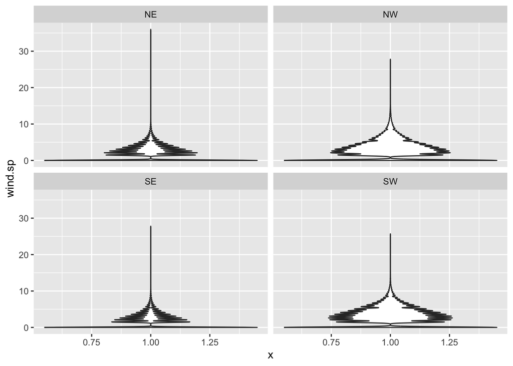

```r
met%>%
  filter(!(region %in% NA)) %>%
ggplot()+geom_violin(mapping = aes(y=wind.sp, x=1)) +facet_wrap(~region, nrow=3)
```

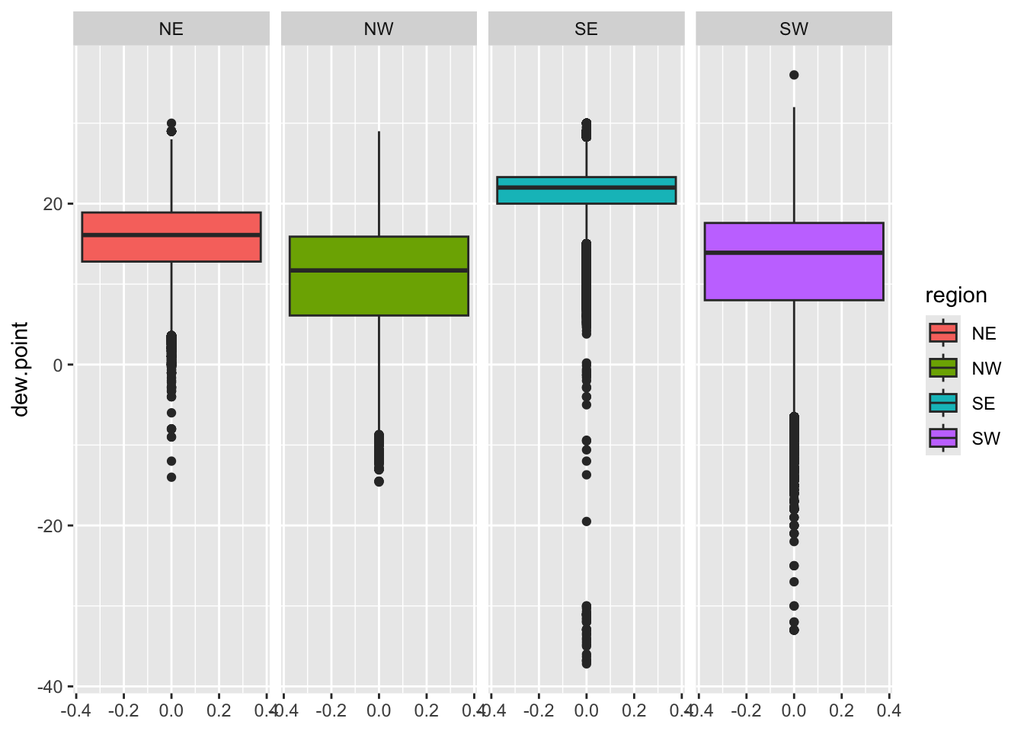

```r
met%>%
  filter(!(region %in% NA)) %>%
ggplot()+geom_boxplot(mapping = aes(y=dew.point, fill=region)) +facet_wrap(~region, nrow=1)
```

## 4. Use geom_jitter with stat_smooth to examine the association between dew point and wind speed by region

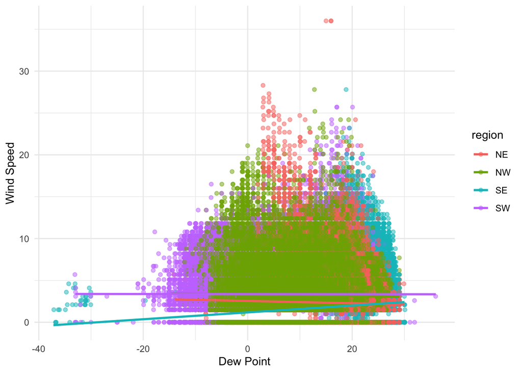

```r
ggplot(met, aes(x = dew.point, y = wind.sp, color = region)) +
  geom_jitter(width = 0.1, height = 0, alpha = 0.5) +  # Jittered points with color by region
  stat_smooth(method = "lm", se = FALSE, formula = y ~ x, aes(group = region)) +  # Linear regression lines by region
  labs(x = "Dew Point", y = "Wind Speed") +  # Axis labels
  theme_minimal()  # Minimal theme
```

[figure not shown]

```r
ggplot(met, aes(x = factor(elev), fill = region)) +
  geom_bar(position = "dodge") +  # Create bars with dodge positioning
  scale_fill_brewer(palette = "Set1") +  # Change colors using Brewer palette
  labs(x = "Elevation Category", y = "Number of Stations", fill = "Region") +  # Axis labels and legend title
  ggtitle("Weather Stations by Elevation Category and Region") +  # Title
  theme_minimal() +  # Minimal theme
  theme(axis.text.x = element_text(angle = 45, hjust = 1))  # Rotate x-axis labels for better readability
```

## Use stat_summary to examine mean dew point and wind speed by region with standard deviation error bars

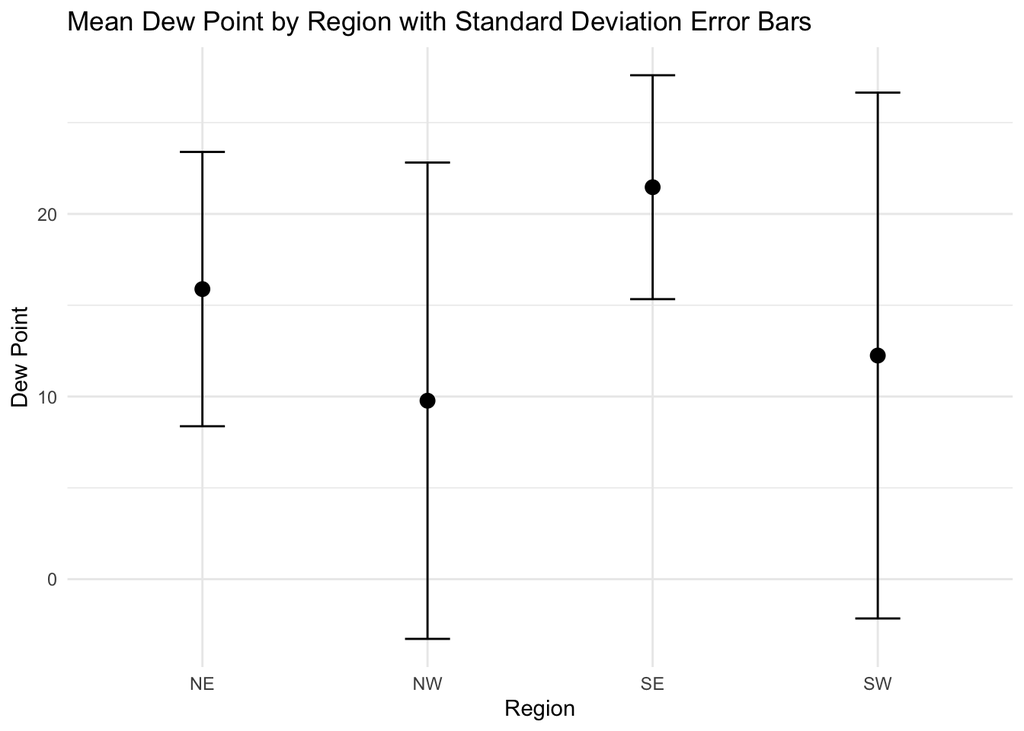

```r
met <- na.omit(met)

# plot for dew point
ggplot(met, aes(x = region, y = dew.point)) +
  stat_summary(fun.data = "mean_sdl", geom = "errorbar", width = 0.2) +
  stat_summary(fun.data = "mean_sdl", geom = "point", size = 3) +
  labs(x = "Region", y = "Dew Point") +
  ggtitle("Mean Dew Point by Region with Standard Deviation Error Bars") +
  theme_minimal()
```

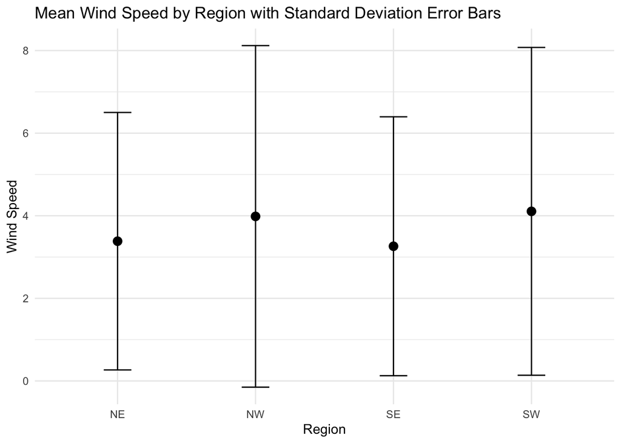

```r
#  plot for wind speed
ggplot(met, aes(x = region, y = wind.sp)) +
  stat_summary(fun.data = "mean_sdl", geom = "errorbar", width = 0.2) +
  stat_summary(fun.data = "mean_sdl", geom = "point", size = 3) +
  labs(x = "Region", y = "Wind Speed") +
  ggtitle("Mean Wind Speed by Region with Standard Deviation Error Bars") +
  theme_minimal()
```

## 7. Make a map showing the spatial trend in relative humidity in the US

```r
library(leaflet)

met <- na.omit(met)

#color palette with custom colors
colors <- colorFactor(
  palette = c("blue", "green", "yellow", "red"),
  domain = met$region
)

# leaflet map
m <- leaflet() %>%
  addTiles() %>%
  setView(lng = -98.00, lat = 39.71, zoom = 4)

#  markers for the top 10 places in relative humidity
top10 <- met[order(-met$rh), ][1:10, ]
m <- m %>%
  addMarkers(
    data = top10,
    lat = ~lat,
    lng = ~lon,
    label = ~paste0("Place: ", rownames(top10), "<br>Relative Humidity: ", round(rh, 2), "%"),
    clusterOptions = markerClusterOptions()
  )

# legend values
legend_values <- levels(colors)

# Add a legend
m <- m %>%
  addLegend(
    "bottomright",
    pal = colors,
    values = legend_values,
    title = "Region",
    opacity = 1
  )

# Display the map
m
```

[interactive chart not shown]

[output not shown]